# Foundations of SQL

## Learning Outcomes

By the end of this course you should be able to:

- Understand basic SQL syntax
- Query tables
- Use join operations
- Edit data tables
- Edit database structure

# 1 Introduction

SQL stands for Structured Query Language, and is designed for interacting with data stored in relational databases - a digital database based on the relational model of data.

We use databases to efficiently store large amounts of data. Using a database allows us to find, add, edit and delete data in an easy and quick manner. Databases can be stored securely in a database, and they can in addition be accessible online, allowing multiple users to interact with them.

There are a number of times when we may want to use databases:

- When our data is too large to store in a single csv or excel file.
- When a number of users need access to data that is being updated.
- When access to data needs to be restricted, such as with sensitive data.

SQL is a way of interacting with a specific type of database using something called the relational model.

A relational database is a collection of tables, each table containing a set of rows and columns. Each row contains the information for a single observation - e.g. a customer, a transaction, a VAT record - while each column contains a specific attribute for all rows in the data - e.g. a name, an id number, a transaction date.

In the below table, we have six attributes for our three observations.

| pID | forename | age | nationality | hair_Colour | eye_Colour |
| --- | --- | --- | --- | --- | --- |
| 1 | Alice | 24 | British | Brown | Blue |
| 2 | Bob | 32 | Canadian | Brown | Blue |
| 3 | Cleo | 29 | Danish | Brown | Blue |

Here we have a unique value in the column *pID*, which is different for each record. This allows us to identify each record by the *pID* attribute rather than the other contents of the record, which may not be unique.

There are many different flavours of SQL, each with slight syntactical differences. Commands you enter to access a PostgreSQL database might have small differences to those used to access a MySQL, Oracle SQL or an SQLite table. As such, some commands might need a slight adjustment to be able to access a specific database system, but there is a wealth of documentation available online for different variants.

We can also use SQL syntax in both R and Python to interact with databases by using packages such as *DBI*, *sqldf*, *dbplyr* (R) and *sqlite3*, *mysql.connector*, *sqlalchemy* (python). In fact, this course was created in part using one of these libraries and SQL’s interactivity with R.

The exercises in this course will be completed by writing code using an online SQLite website where you can upload files and practice basic SQL. Do not use this website for your actual job or to store secure data, only to learn with.

Please go to [sqliteonline.com](https://sqliteonline.com/) for all exercises. You do **not** need to make an account.

The page loaded will look similar to the one shown below. You do not yet need to start using this tool until the exercises, but if you would like to write in the code as it is shown in the course this can be done.

[figure not shown]

The webpage comes with a table ready made for us, called *demo*. We will not be using this in the course. Instead, we will be creating our own tables using sqlite, and importing data onto the page.

Below is a brief description of some of the useful areas of the webpage.

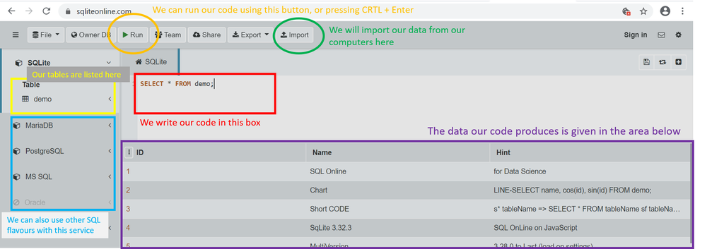

Using the “Run” button will run *all* the code in a script. Keep this in mind if you are writing multiple sections of code, as this may repeat actions you do not want repeated.

# 2 Basic SQL

For the benefit of this document, lets create some temporary data.

How this done, and the syntax below will be explained throughout the course.

*You do not yet need to write these commands on your own device.* If you do, you will need to run one command at a time, rather than all at once like in an R or python script. If you re-run lines of code multiple times an error may be produced.

We suggest if you do want to run the code as we go, to write the code, run it, then remove the code before writing the next statement.

```sql
-- Create an empty table with defined attributes (this line is a comment).
CREATE TABLE IF NOT EXISTS people (
    pid INTEGER PRIMARY KEY,
    forename VARCHAR(255),
    age INTEGER,
    nationality VARCHAR(255),
    hair_colour VARCHAR(255),
    eye_colour VARCHAR(255)
    );
```

```sql
-- Insert values into the created table.
INSERT INTO people (pid, forename, age, nationality, hair_colour, eye_colour)
VALUES (1, 'Alice', 29, 'British', 'Brown', 'Blue'),
       (2, 'Bob', 32, 'Canadian', 'Brown', 'Blue'),
       (3, 'Cleo', 29, 'Danish', 'Brown', 'Blue');
```

In general, SQL is both *case-insensitive*, and *ignores unnecessary whitespace*.

Convention varies, but having all **SQL keywords** in ALL CAPITALS, and all table names and column names in all lowercase is advisable; it makes it easier to distinguish between variables and keywords.

Equally, use whitespace to your advantage to make SQL statements more readable, and do not put spaces in database, table, or column names.

All valid SQL commands end in a semi-colon - this terminates the SQL query.

```sql
-- Example casing convention.
SQLKEYWORDS tablenames columnnames;
```

## 2.1 Types of Operation

SQL can be broadly broken into three sub-sections:

- Querying the data,
- Editing tables of data,
- Editing the actual database structure.

Querying allows a user to gain insights from the data, by *selecting* specific data and *performing operations* upon it.

*Inserting* records, *deleting* records, or *modifying* existing records falls under the second category, editing the contents of the tables.

Editing the database structure itself includes *defining tables*, *creating*, *dropping*, and *altering* them.

## 2.2 Select

For much of our time interacting with a database we will be wanting to extract some information from it.

DQL (Data Query Language) is made up primarily of the *SELECT* keyword. This is used anytime data needs to be returned.

To select data from your table, use the **SELECT** statement.

This can be used to select a subset of columns **FROM** a table by listing them.

The column names follow the **SELECT** statement, and multiple columns can be selected by separating the names by commas.

In the below example we want the *forename* and *age* columns returned from the *people* table we created in the above section.

```sql
SELECT forename, age FROM people;
```

| forename | age |
| --- | --- |
| Alice | 29 |
| Bob | 32 |
| Cleo | 29 |

All of the columns in a database can be returned by passing in a * symbol in place of the column.

```sql
SELECT * FROM people;
```

| pid | forename | age | nationality | hair_colour | eye_colour |
| --- | --- | --- | --- | --- | --- |
| 1 | Alice | 29 | British | Brown | Blue |
| 2 | Bob | 32 | Canadian | Brown | Blue |
| 3 | Cleo | 29 | Danish | Brown | Blue |

We can select the **DISTINCT** results from a column by adding the **DISTINCT** keyword. This will return only the records that are unique.

The **DISTINCT** keyword follows the select statement.

```sql
SELECT DISTINCT hair_colour FROM people;
```

| hair_colour |
| --- |
| Brown |

> **REMINDER:** All valid queries must end with a `;`

In SQL you can refer to a specific column name in a table using the syntax:

```sql
-- A dot after the tablename specifies which column is chosen.
tablename.columnname
```

An example of using dot notation for a column name would be:

```sql
SELECT people.forename FROM people;
```

| forename |
| --- |
| Alice |
| Bob |
| Cleo |

### 2.2.1 Conditions

We often want more specific information than just entire columns of our data.

**WHERE** can be used to add conditions to **SELECT** statements, using logical operators. The records returned to us will only be those that meet the conditions requirements.

- To match values, use the operator *=*. For example *CustomerID = 10*
- To return the opposite, where values do not match, use `<>`. For example. `CustomerID <> 10`
- `>` and `<` can be used when filtering on numeric or date columns. If used on a column of strings, they will compare on an alphabetical basis. For example `a < c < d`

```sql
SELECT * FROM people WHERE nationality = 'British';
```

| pid | forename | age | nationality | hair_colour | eye_colour |
| --- | --- | --- | --- | --- | --- |
| 1 | Alice | 29 | British | Brown | Blue |

As our operations get longer we can separate different statements into different lines for clarity. The below code block is equivalent the the one shown above, but will be more readable.

By not ending a line with a `;` we can go to the next line to write another part of the statement.

```sql
SELECT *
FROM people
WHERE nationality = 'British';
```

| pid | forename | age | nationality | hair_colour | eye_colour |
| --- | --- | --- | --- | --- | --- |
| 1 | Alice | 29 | British | Brown | Blue |

We can combine conditions together using **AND** and **OR**, and conditions can be wrapped in brackets to perform more complicated logical comparisons.

```sql
SELECT *
FROM people
WHERE (nationality <> 'British') AND (age > 30);
```

| pid | forename | age | nationality | hair_colour | eye_colour |
| --- | --- | --- | --- | --- | --- |
| 2 | Bob | 32 | Canadian | Brown | Blue |

Sentences are only complete when they have a proper punctuation mark at the end (. ! ? etc.). In a similar manner SQL statements are only complete once a `;` has been added to the end.

#### 2.2.1.1 In

**IN** can be used to return records where a value is **IN** a list of values.

A list of values is formed using *()* and commas.

*pid* 5 and 9 will not show, as they do not exist in this table.

```sql
SELECT *
FROM people
WHERE pid IN (1, 5, 9);
```

| pid | forename | age | nationality | hair_colour | eye_colour |
| --- | --- | --- | --- | --- | --- |
| 1 | Alice | 29 | British | Brown | Blue |

#### 2.2.1.2 NOT

We can invert conditions by including the **NOT** keyword before a condition. This will return us the values that were not returned in the last example.

```sql
SELECT *
FROM people
WHERE pid NOT IN (1, 5, 9);
```

| pid | forename | age | nationality | hair_colour | eye_colour |
| --- | --- | --- | --- | --- | --- |
| 2 | Bob | 32 | Canadian | Brown | Blue |
| 3 | Cleo | 29 | Danish | Brown | Blue |

#### 2.2.1.3 LIKE

**LIKE** can be used as part of the condition to apply *fuzzy matching* techniques. Fuzzy matching in general returns non-exactly specified queries.

There are two wildcard operators which can be used, to look for a single character, or multiple characters, *_*, and* %*.

For instance, **LIKE ‘p_n’** would match to *pan*, *pin*, or *pen*, but not to *person*, or *penguin*, as it only matches **single character replacements**.

**LIKE ‘p%n’** however, will look for **any number of characters** between the *p* and *n*, so both *pan* and *penguin* will be matched. *This also includes matching zero characters*.

```sql
SELECT * FROM people
WHERE forename LIKE 'Alic%';
```

| pid | forename | age | nationality | hair_colour | eye_colour |
| --- | --- | --- | --- | --- | --- |
| 1 | Alice | 29 | British | Brown | Blue |

```sql
SELECT * FROM people
WHERE forename LIKE '_o%';
```

| pid | forename | age | nationality | hair_colour | eye_colour |
| --- | --- | --- | --- | --- | --- |
| 2 | Bob | 32 | Canadian | Brown | Blue |

**LIKE** is generally *case sensitive*. To get around this, use the **LOWER** (or **UPPER**) keyword and wrap it around the column the filter is being applied to with brackets *()*.

```sql
SELECT * FROM people
WHERE LOWER(nationality) LIKE '%d%';
```

| pid | forename | age | nationality | hair_colour | eye_colour |
| --- | --- | --- | --- | --- | --- |
| 2 | Bob | 32 | Canadian | Brown | Blue |
| 3 | Cleo | 29 | Danish | Brown | Blue |

In SQLite, **LIKE** by default will be case insensitive. It can be switched on for the session by running:

```sql
PRAGMA case_sensitive_like = true;
```

### 2.2.2 Sorting Records

Without explicitly specifying an order to return data in, there is no guarantee that the data will be in any one particular order when returned - it will not default to being sorted on an index number (the primary key).

The **ORDER BY** keyword can be used to specify a specific column, or columns, to order in *ascending*, or *descending* order.

For descending order we use **DESC** after the **ORDER BY** *columnname*.

We can similarly use **ASC** for ascending order.

```sql
SELECT *
FROM people
ORDER BY forename DESC;
```

| pid | forename | age | nationality | hair_colour | eye_colour |
| --- | --- | --- | --- | --- | --- |
| 3 | Cleo | 29 | Danish | Brown | Blue |
| 2 | Bob | 32 | Canadian | Brown | Blue |
| 1 | Alice | 29 | British | Brown | Blue |

We can sort by multiple columns by chaining column names and order methods like below.

```sql
SELECT *
FROM people
ORDER BY age ASC, nationality DESC;
```

| pid | forename | age | nationality | hair_colour | eye_colour |
| --- | --- | --- | --- | --- | --- |
| 3 | Cleo | 29 | Danish | Brown | Blue |
| 1 | Alice | 29 | British | Brown | Blue |
| 2 | Bob | 32 | Canadian | Brown | Blue |

**REMINDER:** The order you list the columns in will affect how the data is sorted. The first column will be sorted by first, then within each unique value the next column will be sorted according to the method listed.

## 2.3 Arithmetic

We can do more than just simply return specified values, as we are using a programming language we can do arithmetic between our columns to return more informative values.

The arithmetic operators include:

- *+* (Add)
- *-* (Subtract)
- *** (Multiply)
- */* (Divide)
- *%* [(Modulo)](https://en.wikipedia.org/wiki/Modulo_operation)

We can therefore get values by performing operations on columns. This can be done either as combinations of columns or to individual columns. For example:

```sql
SELECT forename, age * 365
FROM people;
```

| forename | age * 365 |
| --- | --- |
| Alice | 10585 |
| Bob | 11680 |
| Cleo | 10585 |

The basic syntax for operations is:

```sql
SELECT [column1] [operation] [column2]
FROM [tablename];
```

Whilst not being a hugely informative measurement, we can multiply the columns `pID` and `age` using the following code.

```sql
SELECT pID * age
FROM people;
```

| pID * age |
| --- |
| 29 |
| 64 |
| 87 |

This is useful for scaling or combining values, for example, quantities such as *cost_per_person* could be calculated using the columns *cost* and *number_of_people*.

## 2.4 Aggregates

We will often want to find out aggregate quantities which tell us something about our data.

Examples of aggregates we can use include:

- **COUNT()** - counts the number of records
- **SUM()** - returns the sum of the values of the records
- **AVG()** - returns the mean average of the values of records

These can be particularly useful when used in conjunction with other conditions, allowing us to summarise specific parts of our data.

These are all functions, so they require brackets and us to pass arguments into them.

**NOTE:** **NULL** values are ignored in these statistics.

Below we will find:

- the number of records.
- the total age of all people with blue eyes.
- the average age of all people with names starting with “A”.

```sql
SELECT COUNT(pid) FROM people;
```

| COUNT(pid) |
| --- |
| 3 |

```sql
SELECT SUM(age)
FROM people
WHERE eye_colour = 'Blue';
```

| SUM(age) |
| --- |
| 90 |

```sql
SELECT AVG(age)
FROM people
WHERE forename LIKE 'A%';
```

| AVG(age) |
| --- |
| 29 |

## 2.5 Comments and Whitespace

All single line comments should start with two dashes: *–*. Anything after these will be ignored.

```sql
--DROP TABLE people
```

```sql
/*
DROP TABLE people
DROP TABLE personaldata
*/
```

Likewise, excess whitespace is ignored. Commands can run on multiple lines, with as much whitespace as needed to make the entire command easy to understand (or, in the case below, make the code less legible!).

```sql
SELECT     *

     FROM

  people
              WHERE

eye_colour IS        'Blue';
```

| pid | forename | age | nationality | hair_colour | eye_colour |
| --- | --- | --- | --- | --- | --- |
| 1 | Alice | 29 | British | Brown | Blue |
| 2 | Bob | 32 | Canadian | Brown | Blue |
| 3 | Cleo | 29 | Danish | Brown | Blue |

Be sensible with your whitespace! If you would like further guidance on specific syntax there are multiple style guides available online, such as [this one](https://www.sqlstyle.guide/#query-syntax).

Your best bet will be using your team/department’s style guide if it exists.

> **SIDE NOTE:** You may see in other peoples code comments using /* and */ to begin and end comments. This is another valid form of commenting.

## 2.6 Exercises

Please go to the [SQLite.com](https://sqliteonline.com/) website.

Click “Import” > File “Open” > Navigate to the */data/* folder > Select the *personaldata.sql* file. > Select “Run” > Click Ok > The table will have the same name as the file = *personaldata*

To run a command write it out, then either click “Run”. For some users pressing *Crtl+Enter* may also work. This will run *all* the code within the code script, not just the highlighted code. You may need to remove some code from your script to prevent repeated actions as you progress.

If you have multiple statements returning data within one editor window, you can use the numbers at the bottom of the results table to move between them.

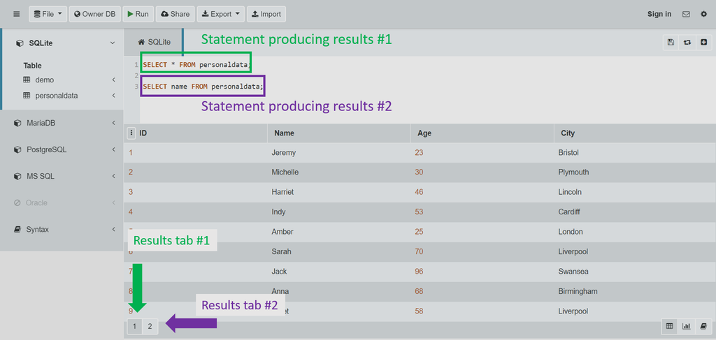

**Questions**

1. Display all the data.
2. Display the names of people who live in “Liverpool”.
3. Display all columns for people above the age of 55 and not from “Lincoln”.
4. Display the IDs, names, and ages of all people with names begining with “J”.
5. Display all the columns in descending order by city for ID < 7.
6. Display average age of people from cities beginning with “L”.

**Answers**

**Question 1**

Display all the data.

```sql
SELECT * FROM personaldata;
```

| ID | Name | Age | City |
| --- | --- | --- | --- |
| 1 | Jeremy | 23 | Bristol |
| 2 | Michelle | 30 | Plymouth |
| 3 | Harriet | 46 | Lincoln |
| 4 | Indy | 53 | Cardiff |
| 5 | Amber | 25 | London |
| 6 | Sarah | 70 | Liverpool |
| 7 | Jack | 96 | Swansea |
| 8 | Anna | 68 | Birmingham |
| 9 | Juliet | 58 | Liverpool |

**Question 2**

Display the names of people who live in “Liverpool”.

```sql
SELECT name FROM personaldata WHERE city = "Liverpool";
```

| Name |
| --- |
| Sarah |
| Juliet |

**Question 3**

Display all columns for people above the age of 55 and not from “Lincoln”.

```sql
SELECT *
FROM personaldata
WHERE age > 55
AND city <> "Lincoln";
```

| ID | Name | Age | City |
| --- | --- | --- | --- |
| 6 | Sarah | 70 | Liverpool |
| 7 | Jack | 96 | Swansea |
| 8 | Anna | 68 | Birmingham |
| 9 | Juliet | 58 | Liverpool |

**Question 4**

Display the IDs, names, and ages of all people with names begining with “J”.

```sql
SELECT id, name, age
FROM personaldata
WHERE name LIKE 'J%';
```

| ID | Name | Age |
| --- | --- | --- |
| 1 | Jeremy | 23 |
| 7 | Jack | 96 |
| 9 | Juliet | 58 |

**Question 5**

Display all the columns in descending order by city for ID < 7.

```sql
SELECT *
FROM personaldata
WHERE id < 7
ORDER BY city DESC;
```

| ID | Name | Age | City |
| --- | --- | --- | --- |
| 2 | Michelle | 30 | Plymouth |
| 5 | Amber | 25 | London |
| 6 | Sarah | 70 | Liverpool |
| 3 | Harriet | 46 | Lincoln |
| 4 | Indy | 53 | Cardiff |
| 1 | Jeremy | 23 | Bristol |

**Question 6**

Display average age of people from cities beginning with “L”.

```sql
SELECT AVG(age)
FROM personaldata
WHERE city LIKE 'L%';
```

| AVG(age) |
| --- |
| 49.75 |

# 3 Data Tables

There are a wide range of properties of data tables themselves we will need to take into account if we want to be able to query, create and manipulate them effectively.

## 3.1 Data Types

SQL has strict data types that are enforced on each column. They are detailed below.

| SQL Data Type | Traditional Data Type | Notes |
| --- | --- | --- |
| VARCHAR(n) | String/Character | Variable length (up to n) |
| CHAR(n) | String/Character | Fixed length (n) |
| INTEGER | Integer |  |
| SERIAL | Incrementing Integer | Auto-Incrementing integer for Primary Key |
| DATE |  | Stores in the form YYYY-MM-DD |
| DATETIME |  | Form YYYY-MM-DD HH:MI:SS |

When creating a new table, each column in the table needs an associated data type.

## 3.2 NULLs

Nulls get placed anywhere there is an absence of data. They cannot be detected using ordinary conditions, and have to use separate statements to pull them out - **IS NULL** and **IS NOT NULL**.

Depending on the flavour of your SQL, **NULL**s may also be shown as **NA**s.

```sql
INSERT INTO people (forename)
VALUES ('David');
```

**Note:** we will discuss what the code above does shortly.

```sql
SELECT * FROM people
WHERE nationality IS NULL;
```

| pid | forename | age | nationality | hair_colour | eye_colour |
| --- | --- | --- | --- | --- | --- |
| 4 | David | NA | NA | NA | NA |

```sql
SELECT * FROM people
WHERE nationality IS NOT NULL;
```

| pid | forename | age | nationality | hair_colour | eye_colour |
| --- | --- | --- | --- | --- | --- |
| 1 | Alice | 29 | British | Brown | Blue |
| 2 | Bob | 32 | Canadian | Brown | Blue |
| 3 | Cleo | 29 | Danish | Brown | Blue |

*pid* is given an automatically incremented value of 4, because it is something called the ‘Primary Key’, which we will now discuss.

## 3.3 Primary Keys

A primary key is a field in a table which **uniquely** identifies each record, and so each value *must be unique*.

**Each table can only have one primary key.**

If a primary key constraint has been created, then no duplicates in the primary key column(s) are allowed - uniqueness is enforced.

```sql
SELECT * FROM people;
```

| pid | forename | age | nationality | hair_colour | eye_colour |
| --- | --- | --- | --- | --- | --- |
| 1 | Alice | 29 | British | Brown | Blue |
| 2 | Bob | 32 | Canadian | Brown | Blue |
| 3 | Cleo | 29 | Danish | Brown | Blue |
| 4 | David | NA | NA | NA | NA |

The people table has the *pid* column as its primary key, so an error is thrown if a duplicate value tries to be inserted.

```sql
-- There already exists a key with the value = 1.
INSERT INTO people VALUES (1, 'Alicia', 24, 'British', 'Brown', 'Blue');
```

*Error: UNIQUE constraint failed: people.pid Execution halted*

Its recommended to use an automatically incrementing integer as each table’s primary key, rather than a value tied to each individual such as an email address. It’s important to consider whether you can guarentee a unique column will be unique no matter how the data changes, what happens if the same individual submits a request twice?

An email address, while nominally unique, is likely to be changed, or reassigned which can cause issues with any links to other data tables.

> **SIDE NOTE:** the *primary key* can consist of multiple columns - a *composite key*.

## 3.4 Foreign Keys

Foreign keys are columns or combinations of columns used to **link two tables together** - the foreign key in a set of data refers to the *primary key* in another set of data.

While foreign keys do not need to be unique, if the column has been formally defined as a foreign key, it will *prevent associated primary key records from being deleted*.

To ensure foreign keys work with SQLite, a **PRAGMA** may need to be set. These are only found in SQLite, and represent global variables. One can be set to make **LIKE** commands case sensitive. The **PRAGMA** will only need to be run once per session.

```sql
PRAGMA foreign_keys = ON;
```

```sql
-- We create a new table `transactions`
-- You can see there are PRIMARY KEY and FOREIGN KEY keywords
CREATE TABLE IF NOT EXISTS transactions (
    transaction_id INTEGER PRIMARY KEY,
    customer_id INTEGER,
    product_code INTEGER,
    product_name VARCHAR(255),
    quantity INTEGER,
    FOREIGN KEY(customer_id) REFERENCES people(pid)
);
```

Within the above SQL **FOREIGN KEY** line, we denote the *customer_id* column as referring to the *pid* column within the original *people* table.

This reference ensures that only records with a *customer_id* matching a *people.pid* can be created, and protects any records within the *people* table which have an *pid* in use within *transactions*.

```sql
-- Inserting records into the table.
INSERT INTO transactions (transaction_id, customer_id, product_code, product_name, quantity)
VALUES (1, 1, 531141, 'Red Door', 4),
       (2, 1, 532413, 'Sofa', 1),
       (3, 3, 531941, 'Blue Lamp', 2);
```

```sql
-- Insert a new record with a consumer_id with no corresponding people.pid value
INSERT INTO transactions VALUES(4, 22, 533819, 'Green Lamp', 23);
```

*Error: FOREIGN KEY constraint failed Execution halted*

This error is returned, as 22 does not exist in the primary key ID column of *people*, and so the above record cannot be inserted into *transactions*.

This is useful as it enforces our two tables being connected.

```sql
-- Remove a value within a foreign key attribute.
DELETE FROM people WHERE pid = 1;
```

*Error: FOREIGN KEY constraint failed Execution halted*

The same error is returned, this time because there is a transaction with a foreign key of *1*, so the *people* record with a *pid* of one is protected.

## 3.5 Cascade

To get around this issue, of records being protected by primary key / foreign key interactions, **CASCADE** can be used. **CASCADE** will take any changes in a table, and propogate (or cascade) them through any related tables.

If a record which is referred to elsewhere is deleted, all connected records will also be deleted - for instance, all transactions for an individual will be deleted.

We create the *transactions* table with **CASCADE**.

```sql
-- We define a FOREIGN KEY and REFERENCE
-- We then tell the data base to CASCADE
-- when we UPDATE or DELETE
CREATE TABLE transactions (
    transaction_id INTEGER PRIMARY KEY,
    customer_id INTEGER,
    product_code INTEGER,
    product_name VARCHAR(255),
    quantity INTEGER,
    FOREIGN KEY(customer_id)
      REFERENCES people(pid)
      ON DELETE CASCADE
      ON UPDATE CASCADE
);
```

We populate the *transactions* table with records.

```sql
INSERT INTO transactions (transaction_id, customer_id, product_code, product_name, quantity)
VALUES (1, 1, 531141, 'Red Door', 4),
       (2, 1, 532413, 'Sofa', 1),
       (3, 3, 531941, 'Blue Lamp', 2);
```

```sql
SELECT * FROM transactions;
```

And this time, as **CASCADE** has been enabled, the record can be dropped, as well as any related transactions.

```sql
DELETE FROM people WHERE pid = 1;
```

```sql
SELECT * FROM people;
```

```sql
SELECT * FROM transactions;
```

[output not shown]

## 3.6 Exercises

Import into SQLiteonline the *missingdata.sql* file. This table is the same as “personaldata” except some values have been lost.

Click “Import” > File “Open” > Navigate to the */data/* folder > Select the *missingdata.sql* file. > Select “Run” > Click Ok > The table will have the same name as the file = *missingdata*

**Questions**

Using only the “missingdata” table.

1. Show the names of each person who has a missing city.
2. Show the names of people who do not have a missing age.
3. Could *id* be used as a primary key? Why or why not? Use code to show this. You can test this by checking if all values are unique.
- **HINT:** use the DISTINCT keyword and a command to check how many records exist.
4. How many missing values are there in the name column?
- **HINT:** We cannot directly count how many missing values there are, but we can count how many total rows are in the table, and how many non-missing values we have.

**Answers**

Lets look at the data first.

```sql
SELECT * FROM missingdata;
```

| ID | Name | Age | City |
| --- | --- | --- | --- |
| 1 | Jeremy | 23 | Bristol |
| 2 | Michelle | 30 | NA |
| 3 | NA | 46 | Lincoln |
| 4 | Indy | NA | Cardiff |
| 5 | Amber | 25 | NA |
| 6 | Sarah | 70 | Liverpool |
| 7 | Jack | NA | Swansea |
| 8 | Anna | 68 | Birmingham |
| 9 | Juliet | 58 | NA |

**Question 1**

Show the names of each person who has a missing city.

```sql
SELECT * FROM missingdata WHERE city IS NULL;
```

| ID | Name | Age | City |
| --- | --- | --- | --- |
| 2 | Michelle | 30 | NA |
| 5 | Amber | 25 | NA |
| 9 | Juliet | 58 | NA |

**Question 2**

Show the names of people who do not have a missing age.

```sql
SELECT name FROM missingdata WHERE age IS NOT NULL;
```

| Name |
| --- |
| Jeremy |
| Michelle |
| NA |
| Amber |
| Sarah |
| Anna |
| Juliet |

**Question 3**

Could *id* be used as a primary key? Why or why not? Use code to show this.

```sql
-- Check to see that the distinct values equals the total values.
SELECT COUNT(DISTINCT id), COUNT(id) FROM missingdata;
```

| COUNT(DISTINCT id) | COUNT(id) |
| --- | --- |
| 9 | 9 |

The values are equal, which shows that the number of unique values is equal to the total number of values. This tells us that every value in the column is unique, we can therefore use *id* as a primary key.

**Question 4**

How many missing values are there in the name column? * **HINT:** We cannot directly count how many missing values there are, but we can count how many total rows are in the table, and how many non-missing values we have.

```sql
SELECT COUNT(*) - COUNT(name) FROM missingdata;
```

| COUNT(*) - COUNT(name) |
| --- |
| 1 |

Here we are counting how many total records we have, then subtracting the number of non-missing values present. Using **COUNT(name)** returns us the number of non-missing values in the column.

# 4 Data Manipulation

**INSERT**, **UPDATE** and **DELETE** are three commands which are used to manipulate the data stored within an SQL table.

We have seen them used to help do other processes earlier in the course, we will now look at them in detail.

## 4.1 Insert

**INSERT** is used to insert records into existing tables of data.

Any inserted records will have to conform to any *primary/foreign key constraints* which have been set up:

- No duplication of primary keys.
- No adding non-existent foreign keys.

```sql
-- Specify the table, then columns, and then the values
-- of the corresponding columns.
INSERT INTO table_name (column_1, column_2, ...)
VALUES (value_1, value_2, ...);
```

If a new record with values for every column is being inserted, no column details need to be specified, but the order of values must match the order of columns.

This is where our data types can come into play.

For example, if a column needs **CHAR** type, it will not allow *27* to be inserted.

```sql
INSERT INTO people
VALUES (4, 'Dani', 34, 'Irish', 'Black', 'Brown');
```

```sql
SELECT * FROM people;
```

We can check what data type each value in a column is by using the *typeof()* function.

```sql
SELECT typeof(pid) FROM people;
```

If we do not specify the value of a column to be inserted, it will automatically take a *NULL*/*NA*.

```sql
-- We are not giving data for all columns
INSERT INTO people (pid, forename)
VALUES (5, 'Eric');
```

```sql
SELECT * FROM people;
```

[output not shown]

## 4.2 Update

**UPDATE** is used to change existing records in a table of data.

To change the values of records we use the following syntax.

```sql
UPDATE table_name
SET column_1 = value_1, column_2 = value_2 ...
WHERE condition;
```

Any record which matches the condition will be modified - if no **WHERE** statement is included, **every** record will be changed! To check whether the condition chosen returns only the record(s) which need to be changed, performing

```sql
SELECT * FROM table_name WHERE condition;
```

before modifying the table is advisable.

Below is an example of updating a value in one column.

We want to change the name ‘Alice’ to ‘Alicia’

We first check the **WHERE** condition we want to use.

```sql
SELECT *
FROM people
WHERE forename = 'Alice';
```

[output not shown]

```sql
UPDATE people
SET forename = 'Alicia'
WHERE forename = 'Alice';
```

```sql
SELECT * FROM people;
```

[output not shown]

## 4.3 Delete

**DELETE** is used to delete existing records in a table of data.

We can determine which records to delete by using a **WHERE** condition.

```sql
DELETE FROM table_name
WHERE condition;
```

As with **UPDATE**, care should be had when specifying a condition to filter by.

> Without the **WHERE** clause **every** record will be deleted.

```sql
DELETE FROM people
WHERE forename = 'Bob';
```

```sql
SELECT * FROM people;
```

[output not shown]

## 4.4 Exercises

These exercises will use both “missingdata” and “personaldata”.

**Question**

1. Insert a new value into “personaldata” with values:
- ID = 10
- Name = “Shirley”
- Age = 78
- City = “Brighton”

and display the whole table.

2. Change the value of “Jeremy”’s age from 23 to 24 in “personaldata” and display the table.
3. Replace the missing age values in “missingdata” with the average age and display the table.
4. Delete the records in “missingdata” with *NULL* values in the City column and display the table.

**Answers**

**Question 1**

1. Insert a new value into “personaldata” with values:
- ID = 10
- Name = “Shirley”
- Age = 78
- City = “Brighton”

and display the whole table.

```sql
INSERT INTO personaldata ('ID', 'Name', 'Age', 'City')
VALUES (10, 'Shirley', 78, 'Brighton');

SELECT * FROM personaldata;
```

| ID | Name | Age | City |
| --- | --- | --- | --- |
| 1 | Jeremy | 23 | Bristol |
| 2 | Michelle | 30 | Plymouth |
| 3 | Harriet | 46 | Lincoln |
| 4 | Indy | 53 | Cardiff |
| 5 | Amber | 25 | London |
| 6 | Sarah | 70 | Liverpool |
| 7 | Jack | 96 | Swansea |
| 8 | Anna | 68 | Birmingham |
| 9 | Juliet | 58 | Liverpool |
| 10 | Shirley | 78 | Brighton |

**Question 2**

Change the value of “Jeremy”’s age from 23 to 24 in “personaldata” and display the table.

```sql
UPDATE personaldata
SET age = 24
WHERE name = "Jeremy";

SELECT * FROM personaldata;
```

| ID | Name | Age | City |
| --- | --- | --- | --- |
| 1 | Jeremy | 24 | Bristol |
| 2 | Michelle | 30 | Plymouth |
| 3 | Harriet | 46 | Lincoln |
| 4 | Indy | 53 | Cardiff |
| 5 | Amber | 25 | London |
| 6 | Sarah | 70 | Liverpool |
| 7 | Jack | 96 | Swansea |
| 8 | Anna | 68 | Birmingham |
| 9 | Juliet | 58 | Liverpool |
| 10 | Shirley | 78 | Brighton |

**Question 3**

Replace the missing age values in “missingdata” with the average age and display the table.

```sql
UPDATE missingdata
SET age = (SELECT AVG(age) FROM missingdata)
WHERE age IS NULL;

SELECT * FROM missingdata;
```

| ID | Name | Age | City |
| --- | --- | --- | --- |
| 1 | Jeremy | 23.00000 | Bristol |
| 2 | Michelle | 30.00000 | NA |
| 3 | NA | 46.00000 | Lincoln |
| 4 | Indy | 45.71429 | Cardiff |
| 5 | Amber | 25.00000 | NA |
| 6 | Sarah | 70.00000 | Liverpool |
| 7 | Jack | 45.71429 | Swansea |
| 8 | Anna | 68.00000 | Birmingham |
| 9 | Juliet | 58.00000 | NA |

**Question 4**

Delete the records in “missingdata” with *NULL* values in the City column and display the table.

```sql
DELETE FROM missingdata
WHERE city IS NULL;

SELECT * FROM missingdata;
```

| ID | Name | Age | City |
| --- | --- | --- | --- |
| 1 | Jeremy | 23.00000 | Bristol |
| 3 | NA | 46.00000 | Lincoln |
| 4 | Indy | 45.71429 | Cardiff |
| 6 | Sarah | 70.00000 | Liverpool |
| 7 | Jack | 45.71429 | Swansea |
| 8 | Anna | 68.00000 | Birmingham |

# 5 Joining Data

## 5.1 Performing Joins

When linking data from separate tables, there are four main ways of linking the data. For a common column to both tables, often a Primary Key and Foreign Key pairing, the data can be joined via a:

- Left Join
- Right Join
- Inner Join
- Outer Join.

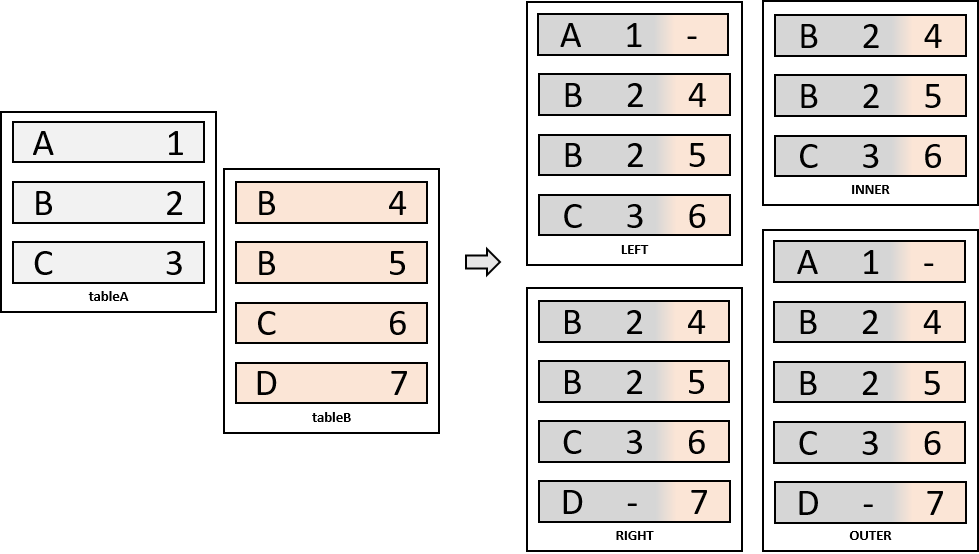

A **Left Join**, the top left of the four output boxes above, returns *all the data from the first table*, and any data from the second data *which can be linked*.

Data is linked if it has the same column values.

A **Right Join**, the bottom left box, does the opposite, and returns *all the data from the second table*, and *any linked data from the first*.

**Note:** A Left Join from table a to table b, is the same as a Right Join from table b to table a.

An **Inner Join**, *keeps only rows which have common values in both tables*.

While an **Outer Join** *keeps all data*, and tries to *match up what it can*.

Joining has noteworthy effects when a value within the joining columns has duplicates - *B* in the above example.

Showing our two tables:

```sql
SELECT * FROM people;
```

```sql
SELECT * FROM transactions;
```

For the table of transaction details, to add a new column to specify customer names, we can do a Left Join as the following.

We can select all rows from a specific table by adding .* after the table name. This is equivalent to writing **SELECT * FROM tablename**, but used when selecting from multiple tables.

```sql
SELECT transactions.*, people.forename
FROM transactions
LEFT JOIN people
ON people.pid = transactions.customer_id;
```

[output not shown]

This has:

- selected all the columns from transactions,
- selected the forename column from people
- joined the *pid* column of people, to the *customer_id* column of transactions

The *customer_id* column is a Foreign Key for the transaction table, and links it to the people table.

SQL can join on multiple columns, by adding to the condition used:

```sql
SELECT tableA.*, tableB.*
FROM tableA
LEFT JOIN tableB
ON tableA.column1 = tableB.column2 AND tableA.column3 = tableB.column4;
```

And like the conditions used in **WHERE** statements, these can be surrounded by sets of brackets to make more complicated logical comparisons.

```sql
SELECT tableA.*, tableB.*
FROM tableA
LEFT JOIN tableB
ON (tableA.column1 = tableB.column2 AND tableA.column3 = tableB.column4)
  OR (tableA.column5 = tableB.column6);
```

## 5.2 Duplicate Data

### 5.2.1 Many-to-One and One-to-Many

If there are duplicates in only one of the tables on the joining colum, such as *B* in the diagram above, or the *customer_id* *1* in the original join example, each of these will be joined with the single value in the other table of data.

Therefore there will be some duplication of some of the data.

This is however *often useful*, such as in the *transaction-people* join above where the name of the user is desired to be attached to every *transaction*, regardless of whether one user has more than one *transaction*.

One of the advantages of joining onto a primary key column is that that column will *always have unique values*.

### 5.2.2 Many-to-Many

If however, there are duplicates in both tables, each matching value on the left, will join with each matching value on the right.

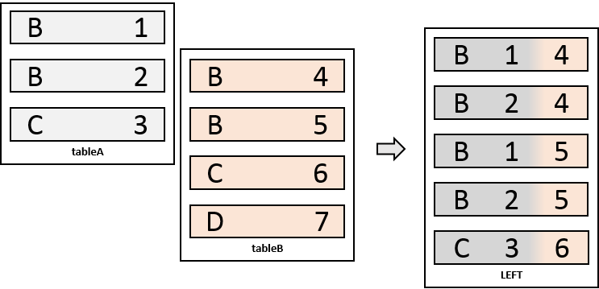

In the example diagram above, the result of the join has *B* values four times, as *2 x 2 = 4*.

## 5.3 Aliasing

In the join above the table names *transactions* and *people* are repeated three times - if queries get very long, and tables have very long names, this could quickly get impractical and untenable.

Instead, table names can be aliased to a new name, and referred to by the shorter name for the rest of the query. In the below query, *transactions* has been aliased as *t*, and *people* has been aliased as *p*. There are two different ways to do this, either with, or without the **AS** keyword.

```sql
SELECT t.*, p.forename
-- first method with AS
FROM transactions AS t
-- second method without AS
LEFT JOIN people p
ON p.pid = t.customer_id;
```

If aliasing is used in this way, all references to table names must be to the aliased version. The original table name - such as *transactions* or *people* - can only be used on the **FROM** and **LEFT JOIN** lines when the aliasing is set up. If the full names are ever used instead of *t* or *p* in the above case, errors will be thrown.

## 5.4 Exercises

To complete these exercises ensure you have the *counties.sql* and *personaldata.sql* files imported into SQLiteonline. Name them “counties” and “personaldata”.

The “counties” table has columns which show a city and their corresponding county names.

**Questions**

1. Display the whole “counties” table.
2. Left Join the “counties” table to the “personaldata”, displaying all the “personaldata” columns and the “county” column from “counties”.
3. Left Join the “counties” table to the “personaldata”, displaying all the “personaldata” columns and the “county” column from “counties”. Use the aliases “p” for “personaldata” and “c” for “county”. This should give the same result as Question 2.

**Answers**

**Question 1**

Display the whole “counties” table.

```sql
SELECT * FROM counties;
```

| ID | City | County |
| --- | --- | --- |
| 1 | Lincoln | Lincolnshire |
| 2 | Liverpool | Lancashire |
| 3 | London | Greater London |
| 4 | Swansea | Swansea |
| 5 | Plymouth | Devon |
| 6 | Cardiff | Cardiff |
| 7 | Birmingham | West Midlands |
| 8 | Bristol | Bristol |
| 9 | Manchester | Greater Manchester |
| 10 | Aberdeen | Aberdeenshire |
| 11 | Belfast | County Atrim/Down |
| 12 | Newcastle | Northumberland |

**Question 2**

Left Join the “counties” table to the “personaldata”, displaying all the “personaldata” columns and the “county” column from “counties”.

It’s important to not that although both tables have an **ID** column, they do not correspond to each other and should not be joined upon for this task. Instead we want to use the *City* column in both tables to join on.

```sql
SELECT personaldata.*, counties.county
FROM personaldata
LEFT JOIN counties
ON personaldata.city = counties.city;
```

| ID | Name | Age | City | County |
| --- | --- | --- | --- | --- |
| 1 | Jeremy | 23 | Bristol | Bristol |
| 2 | Michelle | 30 | Plymouth | Devon |
| 3 | Harriet | 46 | Lincoln | Lincolnshire |
| 4 | Indy | 53 | Cardiff | Cardiff |
| 5 | Amber | 25 | London | Greater London |
| 6 | Sarah | 70 | Liverpool | Lancashire |
| 7 | Jack | 96 | Swansea | Swansea |
| 8 | Anna | 68 | Birmingham | West Midlands |
| 9 | Juliet | 58 | Liverpool | Lancashire |

**Question 3**

Left Join the “counties” table to the “personaldata”, displaying all the “personaldata” columns and the “county” column from “counties”. Use the aliases “p” for “personaldata” and “c” for “county”. This should give the same result as Question 2.

```sql
SELECT p.*, c.county
FROM personaldata AS p
LEFT JOIN counties c
ON p.city = c.city;
```

| ID | Name | Age | City | County |
| --- | --- | --- | --- | --- |
| 1 | Jeremy | 23 | Bristol | Bristol |
| 2 | Michelle | 30 | Plymouth | Devon |
| 3 | Harriet | 46 | Lincoln | Lincolnshire |
| 4 | Indy | 53 | Cardiff | Cardiff |
| 5 | Amber | 25 | London | Greater London |
| 6 | Sarah | 70 | Liverpool | Lancashire |
| 7 | Jack | 96 | Swansea | Swansea |
| 8 | Anna | 68 | Birmingham | West Midlands |
| 9 | Juliet | 58 | Liverpool | Lancashire |

# 6 Database Operations

**CREATE**, **DROP**, and **ALTER** are three SQL commands which are used to make fundamental changes to the definitions of tables.

## 6.1 Create

This course so far has shown the creation of tables without much explaination of *how* to create them.

The syntax for creating new tables is quite straightforward, and mostly consists of a list of column names and column types, with any constraints added in.

The first line, **CREATE TABLE IF NOT EXISTS people (** will create, *if it does not already exist*, a new table by the name of *people*.

Within the brackets, and on separate lines for ease-of-understanding, are lines of the form: **COLUMN_NAME DATA_TYPE [CONSTRAINT],**.

Some constraints can be added on the same line as the column declaration, others must be added at the end.

> **REMINDER:** You must close brackets and end SQL statements with *;*

```sql
CREATE TABLE IF NOT EXISTS people (
    pid INTEGER PRIMARY KEY,
    forename VARCHAR(255),
    age INTEGER CHECK (age < 150),
    nationality VARCHAR(255),
    hair_colour VARCHAR(255),
    eye_colour VARCHAR(255),
    email_address VARCHAR(255) UNIQUE
);
```

Once a table is created, it can be populated using **INSERT**. As seen before, columns do not need to be specified if every column is being referenced.

Both of the SQL code blocks below will perform the same operation in this case.

```sql
INSERT INTO people (pid, forename, age, nationality, hair_colour, eye_colour, email_address)
VALUES (1,'Alice', 29, 'British', 'Brown', 'Blue', 'alice@gmail.com'),
       (2, 'Bob', 32, 'Canadian', 'Brown', 'Blue', 'bob@gmail.com'),
       (3, 'Cleo', 29, 'Danish', 'Brown', 'Blue', 'cleo@gmail.com');
```

```sql
INSERT INTO people
VALUES (1,'Alice', 29, 'British', 'Brown', 'Blue', 'alice@gmail.com'),
       (2, 'Bob', 32, 'Canadian', 'Brown', 'Blue', 'bob@gmail.com'),
       (3, 'Cleo', 29, 'Danish', 'Brown', 'Blue', 'cleo@gmail.com');
```

```sql
SELECT * FROM people;
```

[output not shown]

As well as the primary and foreign keys explored earlier, other constraints can be applied to limit the data which can be put into tables.

### 6.1.1 Check

**CHECK** is used to place a specific condition on a column, such as a number must be more than 0, or a date more than 1900-01-01.

In the above example, a **CHECK** constraint is used to ensure that the age data values are less than 150, as this is (at time of writing) an unfeasible age for a person.

```sql
INSERT INTO people(age) VALUES (160);
```

*Error: CHECK constraint failed: people*

As anticipated, an error is thrown in the table *people*, that its **CHECK** constraint has failed.

### 6.1.2 Unique

**UNIQUE** acts like a primary key, in that it requires every value placed into a column to be unique, such as an email address which while not used as a key, should be different for every user in the database.

```sql
INSERT INTO people(email_address) VALUES ('alice@gmail.com');
```

*Error: UNIQUE constraint failed: people.email_address Execution halted*

This gives an error because the email we are trying to insert here already exists in the *email_address* column.

### 6.1.3 Checking existing constraints

If we did not create the table ourselves we can check to see what constraints have been placed on the columns by querying the table. This returns the statements used to create the table.

```sql
SELECT sql FROM sqlite_master WHERE name = "people";
```

Whilst it is not as nicely formatted, this does give you the ability to see the **CHECK** conditions, data types and **UNIQUE** statements.

Each flavour of SQL will have a different method or command to do this, be sure to check the one which is relevant to you.

## 6.2 Drop

Dropping a table will delete the entire table, and all data stored within it - **be very careful with its use**.

```sql
DROP TABLE IF EXISTS transactions;
```

Remember - a database is a collection of related tables.

Likewise, an entire database can be dropped. Again, be very careful when dropping databases - **all data stored in all tables will be lost!**

```sql
DROP DATABASE 'sql.sqlite';
```

### 6.2.1 Little Bobby Tables - Sanitising your data inputs

[figure not shown]

https://xkcd.com/327/

The above is a cautionary tale on sanitising data inputs - allowing raw SQL to hit your databases can allow for SQL Injections - inserting malicious code which gets directly to your data.

Sometimes this can be used to return data that shouldn’t be available to users. Other times, it can be used to delete tables - such as in the above example.

The student’s name, of *Robert’); DROP TABLE Students;–* would be passed to an insert command - *INSERT INTO students VALUES (name…)*, but would escape the original command due to the *’);*, and then run the second command of *DROP TABLE Students;*, and hide the rest of the original legitimate command by prefacing it with a comment.

```sql
--legitimate value:
--name == Elaine
INSERT INTO students VALUES ('Elaine');

--sql injection
--name == Robert'); DROP TABLE students;--
INSERT INTO students VALUES ('Robert');
DROP TABLE students;
--');
```

We often prevent injections from being dangerous by altering the raw SQL to a clean and usable format. If your database takes a user input then input sanatisation is something your should really think about, although, this is beyond the scope of the course.

## 6.3 Alter

The **ALTER** command can be used to make changes to tables of data - for example adding a new column to an existing table or renaming a column.

```sql
ALTER TABLE people ADD height_cm INTEGER;
```

A new column being added will be filled with NULL values.

```sql
SELECT * FROM people;
```

[output not shown]

**ALTER** can also be used to change constraints on tables - such as adding or removing primary and foreign keys. This is done simply in other flavours of SQL, using the below syntax.

**NOTE:** This will not work in SQLite, in order to get around the lack of this feature you need to create a new table without the constraint and drop the old one. How this is done will be shown shortly.

```sql
ALTER TABLE people DROP CONSTRAINT people_pkey;
```

As we dropped the *transactions* table in the previous section, this is successful - had the foreign key linking *transactions* to *people* still existed, the primary key of *people* would be protected.

Now that the primary key condition has been removed, a record with a duplicate *id* can be inserted.

```sql
INSERT INTO people
VALUES (1, 'Alice2', 20, 'British', 'Black', 'Blue', 'alice2@gmail.com', 130);
```

```sql
SELECT * FROM people;
```

[output not shown]

### 6.3.1 Renaming Columns

We have briefly mentioned that you can rename columns using the **ALTER** keyword. Whilst this is true for the vast majority of SQL flavours, and most likely possible for the flavour you will eventually be working with, it is not the case for sqlite. It does not have every functionality, it is *lite* after all.

Below are examples of how you would rename the column *age* to *age_years* using Oracle SQL and sqlite. You can see that the Oracle method is clearer and shorter.

#### Oracle

We can simply use the RENAME keyword to change the column name.

```sql
ALTER TABLE people
RENAME COLUMN age TO age_years;
```

#### sqlite

In order to change the name of a column in sqlite we need to create a new table with the right column names and then move the data in the original table to the new table.

```sql
-- Rename the table for clarity
ALTER TABLE people RENAME TO people_original;

-- Create the table with the new column names
CREATE TABLE IF NOT EXISTS people (
    pid INTEGER,
    forename VARCHAR(255),
    age_YEARS INTEGER,
    nationality VARCHAR(255),
    hair_colour VARCHAR(255),
    eye_colour VARCHAR(255),
    email_address VARCHAR(255) UNIQUE,
    height_cm INTEGER
);

-- Insert the original data into the new table
INSERT INTO people SELECT * FROM people_original;

-- Drop the original table
DROP TABLE people_original;
```

This method is clearly not as simple, but that’s okay as sqlite would rarely be used in practice, but it is very useful for learning with!

## 6.4 Exercises

For these exercises import the “missingdata”, “counties” and “personaldata” table if they are not already imported. Each time the data is changed in the exercises be sure to keep the changes.

**Questions**

1. Add a new column “more_missing” to “missingdata” table, make it an integer column. Show what it now looks like.
2. Drop the “missingdata” table.
3. Create a new table called “population”. It must have the following characteristics:
- A primary key of integers called “id”.
- A variable character column called “city”.
- An integer column called “population”.
4. Insert the following values into “population”:

```
(1, 'Lincoln', 97541)
(2, 'Plymouth', 234982)
(3, 'Liverpool', 552267)
(4, 'Newcastle', 268064)
(5, 'London', 890800)
```

And display all of “population”.

5. The population of London is incorrect, change it from 890800 to 8908000.
6. Left join the column “population” onto the “personaldata” table using the column “city”.

**Answers**

**Question 1**

Add a new column “more_missing” to “missingdata” table, make it an integer column. Show what it now looks like.

```sql
ALTER TABLE missingdata ADD more_missing INTEGER;

SELECT * FROM missingdata;
```

| ID | Name | Age | City | more_missing |
| --- | --- | --- | --- | --- |
| 1 | Jeremy | 23 | Bristol | NA |
| 2 | Michelle | 30 | NA | NA |
| 3 | NA | 46 | Lincoln | NA |
| 4 | Indy | NA | Cardiff | NA |
| 5 | Amber | 25 | NA | NA |
| 6 | Sarah | 70 | Liverpool | NA |
| 7 | Jack | NA | Swansea | NA |
| 8 | Anna | 68 | Birmingham | NA |
| 9 | Juliet | 58 | NA | NA |

**Question 2**

Drop the “missingdata” table.

```sql
DROP TABLE IF EXISTS missingdata;
```

**Question 3**

Create a new table called “population”. It must have the following characteristics:

- A primary key of integers called “id”.
- A variable character column called “city”.
- An integer column called “population”.

```sql
CREATE TABLE IF NOT EXISTS population (
    id INTEGER PRIMARY KEY,
    city VARCHAR(255),
    population INTEGER
);

SELECT * FROM population;
```

| id | city | population |
| --- | --- | --- |

**Question 4**

4. Insert the following values into “population”:

```
(1, 'Lincoln', 97541)
(2, 'Plymouth', 234982)
(3, 'Liverpool', 552267)
(4, 'Newcastle', 268064)
(5, 'London', 890800)
```

And display all of “population”.

```sql
INSERT INTO population (id, city, population)
VALUES  (1, 'Lincoln', 97541),
        (2, 'Plymouth', 234982),
        (3, 'Liverpool', 552267),
        (4, 'Newcastle', 268064),
        (5, 'London', 890800);

SELECT * FROM population;
```

| id | city | population |
| --- | --- | --- |
| 1 | Lincoln | 97541 |
| 2 | Plymouth | 234982 |
| 3 | Liverpool | 552267 |
| 4 | Newcastle | 268064 |
| 5 | London | 890800 |

**Question 5**

The population of London is incorrect, change it from 890800 to 8908000.

```sql
UPDATE population
SET population = 8908000
WHERE city = "London";

SELECT * FROM population;
```

[output not shown]

**Question 6**

Left join the column “population” onto the “personaldata” table using the column “city”.

```sql
SELECT personaldata.*, population.population
FROM personaldata
LEFT JOIN population
ON personaldata.city = population.city;
```

| ID | Name | Age | City | population |
| --- | --- | --- | --- | --- |
| 1 | Jeremy | 23 | Bristol | NA |
| 2 | Michelle | 30 | Plymouth | 234982 |
| 3 | Harriet | 46 | Lincoln | 97541 |
| 4 | Indy | 53 | Cardiff | NA |
| 5 | Amber | 25 | London | 8908000 |
| 6 | Sarah | 70 | Liverpool | 552267 |
| 7 | Jack | 96 | Swansea | NA |
| 8 | Anna | 68 | Birmingham | NA |
| 9 | Juliet | 58 | Liverpool | 552267 |

# 7 Summary

What we have covered in this course is not the complete set of functionalities of SQL, but we have introduced the basic concepts of using databases with SQL.

The main focus of this course has been an introduction to the three main aspects of SQL

- Querying the data
  - Writing queries using conditions, specififying the output you would like.
  - Joining different tables
- Editing tables of data
  - Changing specific values in the data using **INSERT**, **UPDATE** and **DELETE**.
  - Using keys
- Editing the actual database structure
  - Changing the properties of tables using **CREATE**, **DROP** and **ALTER**.

**Our team is trying to maintain a high response rate to our post-course survey to ensure we keep delivering quality training. Please go to the course on the learning hub and complete the “Post-Course Survey”.**

There is both more theory about relational (and non-relational) databases and more intricacies of the specifics of each flavour of SQL that can be learned. These will come with experience and further study in the area.

# 8 Futher Study

We have looked at simple, small database systems in this course. Large and more complex systems may have more strict requirements in order to operate. Below are some general topics that you should consider reading about in order to deepen your understanding of databases.

## 8.1 Race Conditions

Some database management systems allow queries for the same or different programs to be called at the same time (in parallel). If one query is finding the value of a record, and the other is updating the value of that same record then the order of execution will make a difference on what value is returned. This is known as a race condition.

[This is a nice case study on Race Conditions.](https://medium.com/in-the-weeds/fixing-a-race-condition-c8b475fbb994)

## 8.2 ACID Transactions

ACID transactions are a set of properties that a database transaction can have that enforce the integrity of the database.

The acronym ACID stands for:

- Atomicity
- Consistency
- Isolation
- Durability

Good databases are created, and their transactions designed by using ACID properties.

[For a primer on ACID Transactions click here.](https://blog.yugabyte.com/a-primer-on-acid-transactions/)

## 8.3 RDBMS systems

We have so far briefly discussed that for SQL we have used relational databases. This means that values within a table can relate to other tables, this means we can run queries across multiple tables to get interesting results.

Relational Database Management Systems (RDBMS) are the programs that manage the databases themselves. These make accessing and working with the databases easier than just directly interacting with data.

Examples for RDBMS include; Oracle Database, MySQL and Microsoft SQL Server.

The RDBMS used will dictate the flavour of SQL which needs to be written in.

Why not find out which RDBMS your team / department uses?

## 8.4 NoSQL

Relational databases are one method of storing data, they are particularly good at storing structured data - data that is tabular and easily fits rows and columns. This, however, is not the only type of data that is stored by organisations.

Non-relational databases use unique keys to refer to specific instances of data, without using the rigid structure of related columns. This allows the database to be flexible, as the data type and size of each record can be variable. This makes non-relational database management systems particularly good at storing data such as audio, video and text files in a scalable manner.

NoSQL is a commonly used database that doesn’t rely on structured data.